# Publication Figures

Nick Carleson

December 5, 2018

## Prepare environment and files

### Load libraries

First we load the R packages necessary for analysis.

```r
# input/output
library(readxl)
library(vcfR)
# pop/gen
library(ape)
library(adegenet)
library(pegas)
library(phangorn)
library(poppr)
library(hierfstat)
```

```r
# graphing and dataviz
library(igraph)
library(tidyverse)
library(reshape2)
library(ggrepel)
```

### Load data

Now we will load the data. This consists of 1) SNP data (from the VCF) and 2) metadata about each sample

[output not shown]

```r
metadata_file <- "data/metadata.csv"
strata_defs <- read.table(metadata_file,
                          sep = ",", header = TRUE, stringsAsFactors = FALSE)
```

## VCF filtering

The raw data from STACKS is not good enough to analyze. We will filter on various measures of quality. I’ll wrap these into functions and call them later. These functions have default values, but they should be specified and messed around with because each dataset is unique.

```r
# first filter by depth and quantity of missing data
filter_vcf <- function (x, min_depth = 4, samples_miss1 = 1.0, samples_miss2 = 0.7, vars_miss = 0.2, top_95_quantile_filter = TRUE, remove_nonpolymorphs = TRUE, max_depth = 800) {
  dp <- extract.gt(x, element = "DP", as.numeric = TRUE)

  # Censor variants depth < 8 or > 100
  dp[dp < min_depth] <- NA
  dp[dp > max_depth] <- NA
  x.2 <- x
  x.2@gt[,-1][ is.na(dp) == TRUE] <- NA

  # Censor variants in top 95% quantile
  if (top_95_quantile_filter == TRUE) {
    dp <- extract.gt(x.2, element = "DP", as.numeric = TRUE)
    quants <- apply(dp, MARGIN=2, quantile, probs=c(0.05, 0.95), na.rm=TRUE)
    # Sweep up the file to get rid of the quartiles
    dp2 <- sweep(dp, MARGIN=2, FUN="-", quants[1,])
    dp[dp2 < 0] <- NA
    dp2 <- sweep(dp, MARGIN=2, FUN="-", quants[2,])
    dp[dp2 > 0] <- NA
    x.3 <- x.2
    x.3@gt[,-1][ is.na(dp) == TRUE] <- NA
  }

  # Omit samples with >90% missingness
  dp <- extract.gt(x.3, element = "DP", as.numeric = TRUE)
  # Now omitting samples
  myMiss <- apply(dp, MARGIN = 2, function(y){ sum( is.na(y) ) } )
  myMiss <- myMiss / nrow(dp)
  x.4 <- x.3
  x.4@gt <- x.4@gt[, c(TRUE, myMiss < samples_miss1)]

  # Omit variants with >5% missingness
  dp <- extract.gt(x.4, element = "DP", as.numeric = TRUE)
  # Now omitting vars
  myMiss <- apply(dp, MARGIN = 1, function(y) {sum(is.na(y))})
  myMiss <- myMiss / ncol(dp)
  x.5 <- x.4
  x.5 <- x.5[myMiss < vars_miss, ]

  # Omit samples with >5% missingness
  dp <- extract.gt(x.5, element = "DP", as.numeric = TRUE)
  # Omit samples
  myMiss <- apply(dp, MARGIN = 2, function(y) {sum(is.na(y))})
  myMiss <- myMiss / nrow(dp)
  x.6 <- x.5
  x.6@gt <- x.6@gt[, c(TRUE, myMiss < samples_miss2)]

  # Now remove all variants that are no longer present
  # Measured by a minor allele count > 0
  if (remove_nonpolymorphs == FALSE) {
    return(x.6)
  } else {
    x.7 <- x.6
    x.7 <- x.7[is.polymorphic(x.7, na.omit = TRUE)]
    return(x.7)
  }
}

# Now filter based on minor allele frequency (MAF)
missingGT_maf_filter <- function(x, min_count = 2, isGTmissing = TRUE) {
  maf_matr <- vcfR::maf(x)
  maf_df <- data.frame(maf_matr)
  countslot <- maf_df$Count
  names(countslot) <- rownames(maf_df)

  # subsetting using count column of maf call
  x_mincount <- x
  x_mincount <- x_mincount[(countslot >= min_count),]

  # return end VCF if want to get rid of all NA genotypes
  if (isGTmissing == TRUE) {
    maf <- vcfR::maf(x_mincount)
    maf_df <- data.frame(maf)
    naslot <- maf_df$NA.
    x_nomissing <- x_mincount
    x_nomissing <- x_nomissing[(naslot == 0),]
    return(x_mincount[(naslot == 0),])
  }
  else {
    return(x_mincount)
  }
}
```

### Variant and sample censorship and omission

Now we will call these filtering functions on our data, resulting in a “production VCF” that can be written to a file and reloaded elsewhere to reproduce the figures as shown in the manuscript.

Here are the steps I used for filtering, reflecting the code from the functions above:

1. Censor any allele call with a depth of coverage of 4 or less. In other words, any allele with fewer than 5 reads supporting the call is converted to missing data (NA).
2. Censor SNPs with depth values in the top 95th quantile and the bottom 5th quantile.
3. Omit samples composed of greater than 99.5% missing data across all variants.
4. Omit variants with more than 5% of alleles missing across all samples.
5. Finally, keep only samples having 90% or more of their allele calls.
6. Remove all variants that are not polymorphic i.e., have no allele calls in any of the samples. This is just housekeeping to ensure the SNP count is not falsely inflated.

```r
dp5 <- filter_vcf(vcf_0toMissing, min_depth = 5, samples_miss1 = .995, samples_miss2 = 0.10, vars_miss = 0.05, T, T)
dp5
```

```
## ***** Object of Class vcfR *****
## 90 samples
## 1 CHROMs
## 2,184 variants
## Object size: 2 Mb
## 0.582 percent missing data
## *****        *****         *****
```

Then in the MAF filtering step:

1. Any variant with a minor allele count of only 1 is removed.
2. Any variant with any mising data is removed.

```r
vcf_maffed <- missingGT_maf_filter(dp5, min_count = 2, isGTmissing = TRUE)
vcf_maffed
```

```
## ***** Object of Class vcfR *****
## 90 samples
## 1 CHROMs
## 284 variants
## Object size: 0.3 Mb
## 0 percent missing data
## *****        *****         *****
```

### File conversion

Now we will save our final VCF, with all these filtering steps done to it, and convert it into the file formats we will use for pop gen analysis.

First define the functions we need for these steps.

```r
# Filter strata using the strata set to convert names at the beginning
filter_apply_strata <- function(x, strata_defs, gl = FALSE) {
  strata_defs_filtered <- subset(strata_defs[,], strata_defs$Sample %in% rownames(x@tab))
  return(strata_defs_filtered)
}
```

Now prepare vcfR object for pop gen analysis.

```r
# remove three isolates that were collected from same plant
remove_sampleIDs <- c("B-2", "B-4", "B-5")
vcf_maffed <- vcf_maffed[, !(colnames(vcf_maffed@gt) %in% remove_sampleIDs)]

# convert from vcfR to genind/genlight objects
test1_gi <- vcfR2genind(vcf_maffed)
test1_gl <- vcfR2genlight(vcf_maffed)

# default ploidy for plurivora
ploids <- 2

# filter the strata to the right size and apply to the objects.
strata(test1_gi) <- filter_apply_strata(test1_gi, strata_defs)
pop(test1_gl) <- strata(test1_gl)$Nursery
ploidy(test1_gl) <- ploids

# remove technical reps
no_reps_gi <- test1_gi
no_reps_gi <- no_reps_gi[!is.na(strata(no_reps_gi)$Keep) , ]
# conversion to GL. Needed for PCA later. My PCA currently has technical reps in it... maybe? Weird b/c it doesn't look like it does in the fig
# no_reps_gl <- test1_gl[is.na(strata(no_reps_gi)$Keep), ]

test1_gc <- as.genclone(test1_gi)
no_reps_gc <- as.genclone(no_reps_gi)

# make vcfR objects only containing these sample sets
no_reps_vcf <- vcf_maffed
no_reps_vcf@gt <- vcf_maffed@gt[, c(TRUE, colnames(vcf_maffed@gt)[-1] %in% rownames(no_reps_gc@tab) )]
no_reps_cc_vcf <- vcf_maffed
no_reps_cc_vcf@gt <- vcf_maffed@gt[, c(TRUE, colnames(vcf_maffed@gt)[-1] %in% rownames(clonecorrect(no_reps_gc, ~Nursery)@tab))]
```

## Population genetics

### Principal component analysis

#### Figure 1

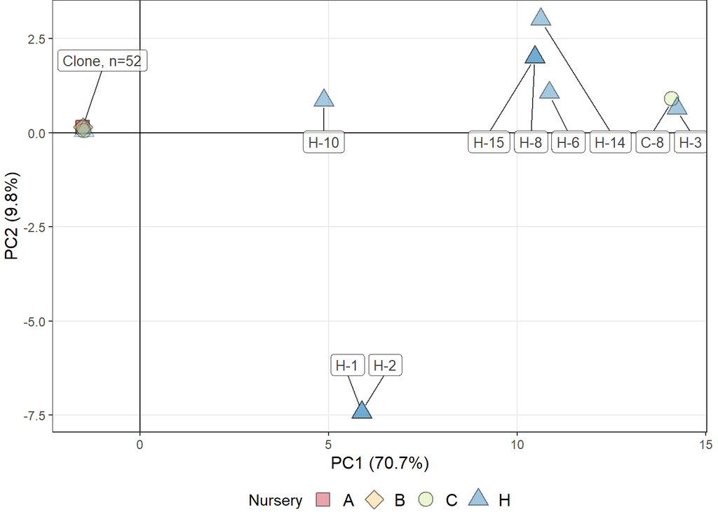

```r
n_dims <- 4
pca1 <- glPca(test1_gl, nf = n_dims)
iPst.pca.scores <- as.data.frame(pca1$scores)
iPst.pca.scores$pop <- pop(test1_gl)
iPst.pca.scores$sample <- rownames(iPst.pca.scores)

# subset PCA to have no technical reps
iPst.pca.scores <- iPst.pca.scores[test1_gl@ind.names %in% rownames(no_reps_gc@tab),]
iPst.pca.scores$pop <- no_reps_gc$strata$Nursery

# these are the diverse samples (observed and noted from the NJ tree)
cluster2_samples <- c('H-1', 'H-2_1', 'H-2_2', 'H-3', 'H-6_1', 'H-6_2', 'H-8_1', 'H-8_2',
              'H-10', 'H-14', 'H-15', 'C-8')
# separate the clade of cryptic diversity ('diverse') and clone
# to later add separate geom_points for clone (jittered) and non-clone (non-jittered)
iPst.pca.scores.diverse <- iPst.pca.scores[(iPst.pca.scores$sample %in% cluster2_samples),]
iPst.pca.scores.clone <- iPst.pca.scores[!(iPst.pca.scores$sample %in% cluster2_samples),]

# fix labels for each set
# Get rid of tech rep labels - this is technical-replicate-agnostic
iPst.pca.scores.diverse$sample <- gsub("_[0-9]", "", iPst.pca.scores.diverse$sample)
# pop(iPst.pca.scores.diverse)
# If a sample is NOT diverse, do NOT label it. NA gives a warning, blank text does not
iPst.pca.scores.clone$sample <- ""
# but come up with a label for the clone along with coordinates to plot the label
clone_label <- data.frame(sample = "Clone",
                          PC1 = median(iPst.pca.scores.clone$PC1),
                          PC2 = median(iPst.pca.scores.clone$PC2))

# calculate percent variance explained by first two eigenvalues
pc1_eig <- round(pca1$eig[1]/sum(pca1$eig), digits = 3)
pc2_eig <- round(pca1$eig[2]/sum(pca1$eig), digits = 3)

# now plot PCA scatter plot
p12 <- ggplot(data = iPst.pca.scores.diverse)
p12 <- p12 + geom_hline(yintercept = 0)
p12 <- p12 + geom_vline(xintercept = 0)
p12 <- p12 + geom_point(data = iPst.pca.scores.diverse, size=4.5, stroke = 0.69, alpha = 0.45, colour = "black",
                        aes(x = PC1, y=PC2, fill= pop, shape = pop))
p12 <- p12 + geom_point(data = iPst.pca.scores.clone, size=4.5, stroke = 0.69, alpha = 0.05, colour = "black",
                        aes(x = PC1, y=PC2, fill= pop, shape = pop))
p12 <- p12 + scale_shape_manual(values = c(22, 23, 21, 24), name = "Nursery")
p12 <- p12 + scale_fill_manual(values = spectral(length(levels(iPst.pca.scores$pop))), name = "Nursery")
adj_element_text = (5/14)
y_limits <- c(0.1, -6.5)
x_limits <- c(-0.1, 15.1)
p12 <- p12 + geom_label_repel(data = iPst.pca.scores.diverse, aes(label=sample, x = PC1, y = PC2),
                             alpha = 0.75, size = 10*adj_element_text, point.padding = 0.75,
                             force = 3, show.legend = FALSE, min.segment.length = 0.25, box.padding = unit(0.1, "lines"),
                             xlim = x_limits, ylim = y_limits,
                             seed = 56)
p12 <- p12 + theme_bw()
p12 <- p12 + theme(plot.title = element_blank(),
                   axis.text = element_text(size = 9),
                   axis.title = element_text(size = 12),
                   panel.grid.minor = element_blank(),
                   legend.text = element_text(size = 12),
                   legend.position = "bottom",
                   legend.margin = margin(0,0,0,0),
                   legend.box.margin = margin(0,0,0,0),
                   plot.margin = margin(0, 6, 0, 1))
p12 <- p12 + labs(x = paste("PC1 (", pc1_eig*100, "%)", sep = ""),
                  y = paste("PC2 (", pc2_eig*100, "%)", sep = ""))
p12 <- p12 + geom_label_repel(data = clone_label,
                        aes(x = PC1, y = PC2,
                            label = paste(sample, ", n=", nrow(iPst.pca.scores.clone), sep = "")),
                        size = 10*adj_element_text, alpha = 0.75, show.legend = FALSE,
                        force = 1, point.padding = .75, min.segment.length = .25,
                        ylim = c(2.5, 1.5), seed = 41) +
  coord_fixed()

p12
```

```r
ggplot2::ggsave("figures/PCA_pc1_pc2.svg", plot = p12, width = 3.25, height = 2.75, units = "in")
```

### Minimum spanning network

#### Figure 2

```r
# calculate and create MSN object
setPop(no_reps_gc) <- ~Nursery
no_reps_gc_sub <- popsub(no_reps_gc, blacklist = character(0))
no_reps_gc_dist <- diss.dist(no_reps_gc_sub, percent = TRUE, mat = FALSE)
min_span_net <- poppr.msn(no_reps_gc_sub, no_reps_gc_dist, showplot = FALSE, include.ties = TRUE)
# calculate edge weight cutoff, emphasizing clone
min_span_net_dists <- E(min_span_net$graph)$weight
# a cutoff of the 90th percentile was selected for edges that should be plotted
cutoff_dist <- quantile(min_span_net_dists, 0.9)

# plot MSN
svg("figures/msn.svg")
set.seed(703)
plot_msn <- plot_poppr_msn(no_reps_gc_sub,
               min_span_net,
               inds = "NONE",
               mlg = FALSE,
               gadj = 50,
               gweight = 1,
               palette = spectral,
               beforecut=TRUE,
               cutoff = cutoff_dist,
               quantiles = FALSE,
               pop.leg = TRUE,
               size.leg = TRUE,
               scale.leg = TRUE,
               nodelab = 30,
               layfun = igraph::layout_with_gem,
               nodescale = 50
               )
dev.off()
```

### Fst

#### Figure 3

Write the function

```r
fst_workflow <- function(x, formula) {
  setPop(x) <- formula

  # Calculate Fst pairwise between samples
  x.fst <- pairwise.fst(x, res.type = "matrix")

  x.hierfstat <- genind2hierfstat(x)
  # Calculate basic statistics, other than Fst
  x.stats <- basic.stats(x.hierfstat)

  # Show pca plot where each point is one population
  dist <- genet.dist(x.hierfstat, method = "Cp")
  biplot(ape::pcoa(as.matrix(dist)), rn = levels(pop(x)))

  # Calculate pca for each individual sample, color by population
  x.hierfstat$sample <- rownames(x@tab)
  some_pca <- indpca(x.hierfstat[,1:ncol(x.hierfstat)-1], ind.labels = x.hierfstat$sample)
  plot(some_pca, col = as.numeric(x.hierfstat[,1]))

  # reshape data (tidy/tall form)
  dat2 <- x.fst %>%
    as_tibble() %>%
    rownames_to_column('Var1') %>%
    gather(Var2, value, -Var1) %>%
    mutate(
      Var1 = rep(rownames(x.fst), 4)
    )
  return(dat2)

  # plot data
  ggplot(dat2, aes(fct_inorder(Var1), fct_inorder(Var2))) +
    geom_tile(aes(fill = value)) +
    geom_text(aes(label = round(value, 3))) +
    scale_fill_gradient(low = "white", high = "red")  +
    xlab("Nursery") +
    ylab("Nursery") +
    guides(fill = FALSE)
}
```

Execute function on our data

```r
test1_gc_contractedmlgs <- test1_gc
mlg.filter(test1_gc_contractedmlgs, distance = "diss.dist", algorithm = "farthest_neighbor") <- 1
test1_gc_cc <- clonecorrect(test1_gc_contractedmlgs, strata = NA)
test1_gc_cc_fst <- fst_workflow(test1_gc_cc, ~Nursery)
```

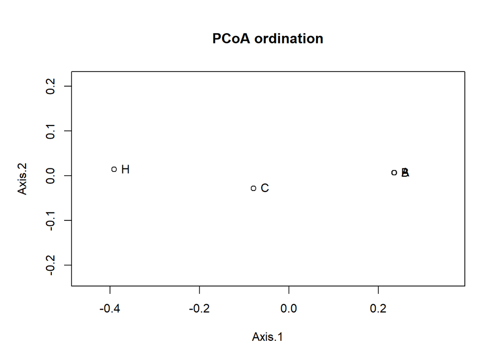

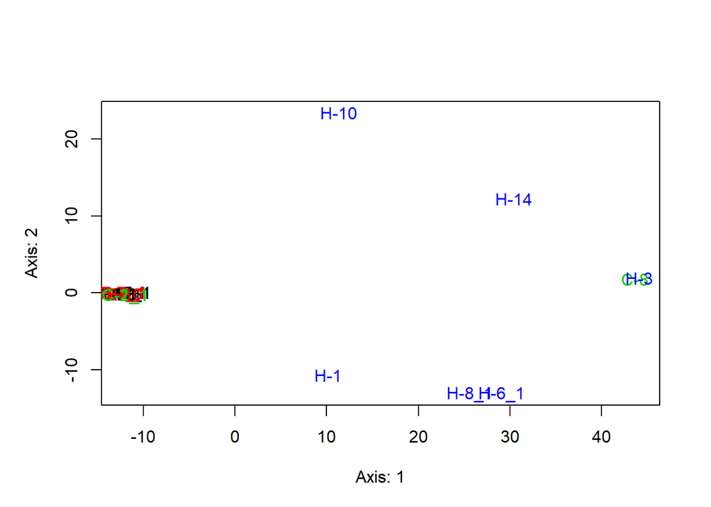

```r
# recast fst data into matrix, remove triangle, remelt, then plot
test1_gc_cc_fst_dcast <- dcast(test1_gc_cc_fst, Var1~Var2)[,-1]
test1_gc_cc_fst_dcast[lower.tri(test1_gc_cc_fst_dcast)] <- NA
test1_gc_cc_fst_recast <- as.data.frame(test1_gc_cc_fst_dcast)
test1_gc_cc_fst_recast$Nursery <- colnames(test1_gc_cc_fst_recast)
test1_gc_cc_fst_recast <- na.omit(melt(test1_gc_cc_fst_recast, 'Nursery', variable.name = "Nursery2"))
# plot reformatted data
test1_gc_cc_fst_ggplot <- ggplot(test1_gc_cc_fst_recast, aes(fct_inorder(Nursery), fct_inorder(Nursery2))) +
    geom_tile(aes(fill = value)) +
    geom_text(aes(label = round(value, 3)), size = 6) +
    scale_fill_gradient(low = "white", high = "red")  +
    labs(x = "Nursery", y = "Nursery") +
    guides(fill = FALSE) +
    theme()
ggsave("figures/fst_heatmap.svg", test1_gc_cc_fst_ggplot, units = "in", width = 3.25, height = 2.75)
```

### Depth plots

#### Supplementary Figure 1

Write function

```r
boxplot_depth_het <- function(x_gl, x_gc, x_vcf, strata) {
  # this lets us set the pop as the cluster
  identities <- snapclust(x_gc, 2)
  geom_identities <- find.clusters(x_gc, choose.n.clust = FALSE, criterion = 'diffNgroup', n.pca = 10)
  set.seed(105)
  geom_identities_k2 <- find.clusters(x_gc,  n.clust = 2, max.n.clust = 2, choose.n.clust = FALSE, criterion = 'diffNgroup', n.pca = 10)
  clustering_membership <- geom_identities_k2$grp
  strata_defs_filtered <- strata
  strata_defs_filtered$cluster <- clustering_membership
  x_gl_popcluster <- x_gl
  x_gl_poptown <- x_gl
  pop(x_gl_popcluster) <- strata$cluster
  pop(x_gl_poptown) <- strata$Nursery

  # snapclust is very close to genetic distance
  clusters <- clustering_membership
  ploids <- ploidy(x_gl_popcluster)
  # get depth, make data frame for boxplotting these all together
  dp <- extract.gt(x_vcf, element = "DP", as.numeric = TRUE)
  myDepth <- apply(dp, MARGIN = 2, function(y){ mean(y, na.rm = TRUE) })

  mean_dps <- apply(dp, MARGIN = 2, mean, na.rm = TRUE)
  quants_mean <- quantile(mean_dps, probs=c(0.05, 0.95), na.rm = TRUE)
  # upper quantile of mean depth
  bot <- mean_dps[mean_dps < quants_mean[1]]
  # lower quantile of mean depth
  top <- mean_dps[mean_dps > quants_mean[2]]

  # get heterozygosity
  all_het <- is_het(extract.gt(x_vcf), na_is_false = TRUE)
  myHet <- colSums(all_het)
  t_dp <- data.frame(t(dp))
  t_dp$Sample <- rownames(t_dp)
  t_dp$Cluster <- clusters
  t_dp$Ploidy <- ploids
  t_dp$Heterozygosity <- myHet
  t_dp$Nursery <- strata_defs_filtered$Nursery

  Nursery_colors <- c(t_dp$Nursery)
  names(Nursery_colors) <- Nursery_colors
  rainbow_pal <- rainbow(4)
  spectral_pal <- spectral(4)
  t_dpf <- melt(t_dp, c('Sample', 'Cluster', 'Ploidy', 'Heterozygosity', 'Nursery'), variable.name = "Index", value.name = "Depth")

  # calculate some more stats
  mean_dp_1ploidy <- mean(t_dpf$Depth[t_dpf$Ploidy == 1])
  mean_dp_2ploidy <- mean(t_dpf$Depth[t_dpf$Ploidy == 2])

  # Sort data frame be samples with highest mean depth
  t_dpf_sorted <- t_dpf %>%
    group_by(Sample) %>%
    summarise(avg = mean(Depth, na.rm = TRUE)) %>%
    right_join(t_dpf, by = c("Sample")) %>%
    arrange(desc(avg), desc(Depth)) %>%
    select(-avg) %>%
    ungroup
  # Retrieve the sorted order
  samples_in_order <- unique(t_dpf_sorted$Sample)
  samples_in_order_df <- data.frame(samples_in_order)
  # Add in nurseries as a column in the correct order from the strata definitions
  samples_in_order_df$Nursery <- strata_defs_filtered[ order(match(strata_defs_filtered$Sample, samples_in_order_df$samples_in_order)),]$Nursery
  samples_in_order_df$Nursery_color <- NA
  samples_in_order_df[samples_in_order_df$Nursery == "A",]$Nursery_color <- spectral_pal[1]
  samples_in_order_df[samples_in_order_df$Nursery == "B",]$Nursery_color <- spectral_pal[2]
  samples_in_order_df[samples_in_order_df$Nursery == "C",]$Nursery_color <- spectral_pal[3]
  samples_in_order_df[samples_in_order_df$Nursery == "H",]$Nursery_color <- spectral_pal[4]

  depth_boxplot <- ggplot(t_dpf_sorted, aes(fct_inorder(Sample), Depth, fill = Heterozygosity, color = Cluster)) +
    geom_boxplot() +
    theme_bw() +
    scale_fill_gradient2(midpoint = quantile(myHet, c(0.05, 0.95), na.rm = TRUE)[2], high = "#018571", mid = "#dcdcdc", low = "#a6611a", name = "Het. Loci") +
    scale_color_manual(values = c("blue4", "greenyellow"))  +
    geom_hline(aes(yintercept=mean(t_dpf$Depth, na.rm = TRUE)),
               color = "springgreen3", linetype="dashed", alpha = 0.75, size = 1) +
    theme(axis.text.x = element_text(angle = 60, hjust = 1,
                                     color = samples_in_order_df$Nursery_color),
          panel.grid.major.x = element_blank(),
          panel.grid.minor.x = element_blank()) +
    labs(x = "")
  return(depth_boxplot)
}
```

```r
strata_defs_filtered <- subset(strata_defs[,], strata_defs$Sample %in% (test1_gl@ind.names))
depth_plot <- boxplot_depth_het(test1_gl, test1_gc, vcf_maffed, strata_defs_filtered)
ggsave(filename = "figures/depth_boxplots.png", depth_plot, width = 15, height = 6)
```

### Phylogenetic tree

#### Supplementary Figure 2

First calculate and prepare the tree

```r
set.seed(102)
geo_tree <- aboot(x = test1_gc, sample = 999, tree = 'nj', missing = "ignore", quiet = TRUE, showtree = FALSE, distance = prevosti.dist, cutoff = 75)
spectral_pal <- spectral(length(levels(pop(test1_gc))))
cols <- spectral_pal[pop(test1_gc)]
```

Now plot the tree

```r
svg("figures/nj_phylogeny.svg", width = 10, height = 10)

# prep dataframe that has the info I need
filtered_gc_info <- data.frame(Sample = strata(test1_gc)$Sample,
                               Source = strata(test1_gc)$Source,
                               Nursery = strata(test1_gc)$Nursery,
                               ITS = strata(test1_gc)$base_ITS_new)

setPop(test1_gc) <- ~Nursery
spectral_pal <- spectral(length(levels(pop(test1_gc))))
nursery_cols <- spectral_pal[pop(test1_gc)]

plot.phylo(ladderize(midpoint(geo_tree)), cex = 0.8, font = 2, adj = 0,
           label.offset = 0.0125, underscore = TRUE, tip.color = nursery_cols,
           type = "fan", align.tip.label = TRUE, open.angle = 10)

# draw boostraps
nodelabels(round(geo_tree$node.label, 1),  adj = c(1.3, -0.5),
           frame = "n", cex = 0.8,font = 3, xpd = TRUE)

# add legend
legend(-0.2,0.2, legend = levels(pop(test1_gc)), pch = 22, pt.bg = spectral_pal, pt.cex = 2.5, title = "Nursery")

# add scale
axisPhylo(xaxp= c(2, 9, 7))

# add dimension for collection source
setPop(test1_gc) <- ~Source
tip_pal <- virid(length(levels(pop(test1_gc))))
tip_cols <- tip_pal[pop(test1_gc)]
tiplabels(frame = "n", cex = 2, font = 3, xpd = NA, offset = 0.09, pch = 19, col = tip_cols)
legend(-0.05,0.2, legend = levels(pop(test1_gc)), pch = 22, pt.bg = tip_pal, pt.cex = 2.5, title = "Source")

# add factor for allele at SNP in ITS
setPop(test1_gc) <- ~base_ITS_new
tip_pal <- funky(length(levels(pop(test1_gc))))
tip_cols <- tip_pal[pop(test1_gc)]
tiplabels(frame = "n", cex = 2, font = 3, xpd = NA, offset = 0.12, pch = 19, col = tip_cols)
legend(0.11,0.2, legend = levels(pop(test1_gc)), pch = 22, pt.bg = tip_pal, pt.cex = 2.5, title = "ITS")

dev.off()
```

### Population diversity

#### Table 1

```r
for_div_stats <- poppr(no_reps_gc, strata = ~Nursery)
for_rbard <- poppr(no_reps_gc, clonecorrect = TRUE, sample = 999, strata = ~Nursery)
```

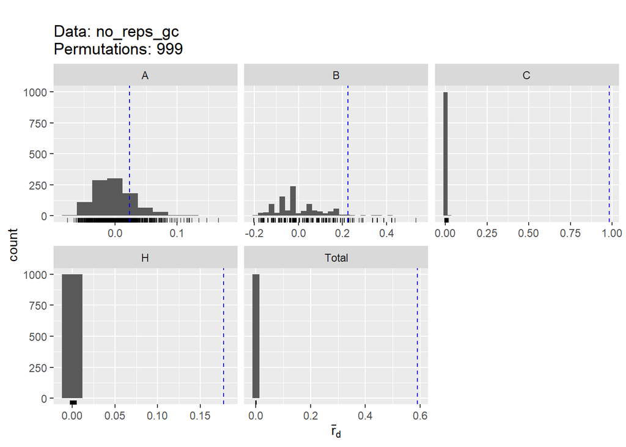

### AMOVA

#### Table 2

```r
amova_noreps_cc_pegas <- poppr.amova(no_reps_gc, hier= ~Nursery, clonecorrect = TRUE, threshold = 1, method = "pegas", nperm = 100)
```

```
##
##  No missing values detected.
```

```r
amova_diffs <- amova_noreps_cc_pegas$tab
amova_diffs$pct_variance <- c(amova_noreps_cc_pegas$varcomp[,'sigma2'], NA)
amova_diffs$p_value <- c(amova_noreps_cc_pegas$varcomp[,'P.value'], NA)
amova_diffs[c(3, 1, 2, 4, 5)]
```

```
##         df       SSD       MSD pct_variance p_value
## Nursery  3  733.4433 244.48109     29.21895       0
## Error   22 1422.7875  64.67216     64.67216      NA
## Total   25 2156.2308  86.24923           NA      NA
```

## Fungicides

Load in Excel data

```r
raw_data <- read.table("data/fungicide_table.tsv", header = TRUE, sep = "\t")
```

Clean table

```r
cleaned_data <- raw_data %>%
  map_dfr(~ gsub("\\*", NA, .x))


colnames(cleaned_data)[6] <- "mef"
colnames(cleaned_data)[7] <- "phos"

class(cleaned_data$mef) <- "double"
class(cleaned_data$phos) <- "double"
class(cleaned_data$Trial) <- "integer"

fung_cleaned_data <- melt(cleaned_data, c('Nursery', 'Species', 'Isolate', 'Trial', 'Rep'),
                          variable.name = "Fungicide", value.name = "EC50")

fung_cleaned_data_trans <- fung_cleaned_data %>%
  mutate(log_EC50 = log(EC50)) %>%
  mutate(log10_EC50 = log10(EC50)) %>%
  mutate(root_EC50 = sqrt(EC50)) %>%
  mutate(reciprocal_EC50 = 1/EC50)
```

Prepare summaries for bar charts, both with raw data and log-transformed data

```r
fung_summary_log <- fung_cleaned_data_trans %>%
  group_by(Isolate, Fungicide) %>%
  summarize(mean = mean(log_EC50, na.rm = TRUE),
            median = median(log_EC50, na.rm = TRUE),
            sd = sd(log_EC50, na.rm = TRUE)) %>%
  data.frame(stringsAsFactors = FALSE)
levels(fung_summary_log$Fungicide) <- c("A", "B")
fung_summary_cast_log <- dcast(fung_summary_log, Isolate ~ Fungicide, value.var = 'mean') %>%
  map_dfr(~ gsub("NaN", NA, .x))
fung_summary_cast_log$Nursery <- sapply(strsplit(fung_summary_cast_log$Isolate, "-"), `[`, 1)

fung_summary_raw <- fung_cleaned_data_trans %>%
  group_by(Isolate, Fungicide) %>%
  summarize(mean = mean(EC50, na.rm = TRUE),
            median = median(EC50, na.rm = TRUE),
            sd = sd(EC50, na.rm = TRUE)) %>%
  data.frame(stringsAsFactors = FALSE)
levels(fung_summary_raw$Fungicide) <- c("A", "B")
fung_summary_raw$Nursery <- sapply(strsplit(fung_summary_raw$Isolate, "-"), `[`, 1)
fung_summary_cast <- dcast(fung_summary_raw, Isolate ~ Fungicide, value.var = 'mean') %>%
  map_dfr(~ gsub("NaN", NA, .x))
fung_summary_cast$Nursery <- sapply(strsplit(fung_summary_cast$Isolate, "-"), `[`, 1)
```

### Fungicide sensitivity distribution

#### Figure 4

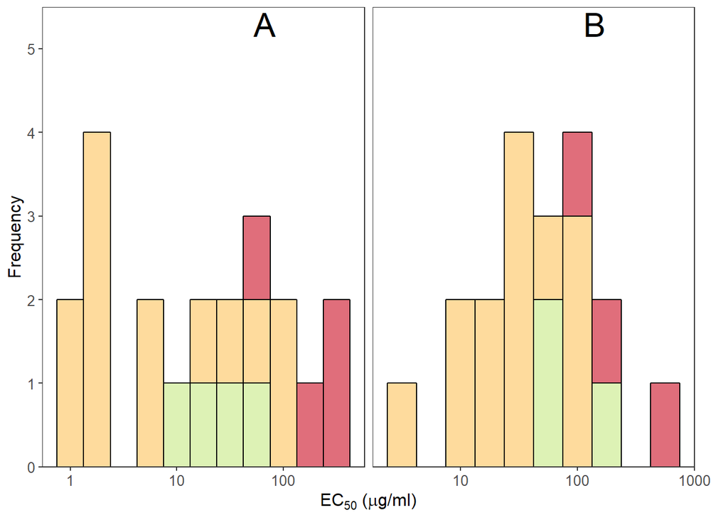

```r
fung_distr <- ggplot(fung_summary_raw, aes(mean)) +
  geom_histogram(aes(fill = Nursery), na.rm = TRUE, binwidth = 0.25,
                 alpha = 0.75, position = "stack",
                 color = "black") +
  scale_fill_manual(values = spectral(4)) +
  labs(x = expression("EC"[50]*" ("*mu*"g/ml)"), y = "Frequency") +
  facet_wrap(vars(Fungicide), scales = "free_x") +
  theme_bw() +
  theme(panel.grid = element_blank(),
        plot.margin = margin(5, 23, 5, 5),
        strip.background = element_blank(),
        strip.text = element_blank(),
        axis.text = element_text(size =
                                   10),
        text = element_text(size = 12),
        legend.position = "none") +
  geom_text(data = dplyr::distinct(fung_summary_raw, Fungicide),
            aes(label = Fungicide),
            x = Inf, y = Inf, hjust = 5, vjust = 1.2, size = 8) +
  scale_x_continuous(trans = "log10") +
  scale_y_continuous(expand = c(0, 0), limits = c(0, 5.5))

fung_distr
```

```r
ggsave("figures/fung_resist_distr.png", fung_distr,
       width = 3.25, height = 2.5, units = "in")
```

### Fungicide sensitivity correlation

#### Figure 5

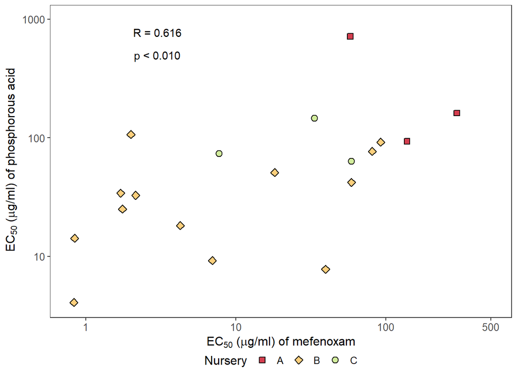

```r
# Spearman's test (R), not Pearson's (r) or R^2
fung_summary_cast_nona <- fung_summary_cast[!is.na(fung_summary_cast$B),]
fung_summary_cast_nona$A <- as.numeric(fung_summary_cast_nona$A)
fung_summary_cast_nona$B <- as.numeric(fung_summary_cast_nona$B)
range_A <- range(fung_summary_cast_nona$A)
range_B <- range(fung_summary_cast_nona$B)
spearmans <- cor.test(fung_summary_cast_nona$A, fung_summary_cast_nona$B, method = "spearman")

fung_cor <- ggplot(fung_summary_cast_nona) +
  geom_point(aes(x = A, y = B, fill = Nursery, shape = Nursery), na.rm = TRUE,
             size = 2.5, stroke = 0.69) +
  scale_fill_manual(values = spectral(4), name = "Nursery") +
  scale_shape_manual(values = c(22, 23, 21), name = "Nursery") +
  labs(x = expression("EC"[50]*" ("*mu*"g/ml) of mefenoxam"),
       y = expression("EC"[50]*" ("*mu*"g/ml) of phosphorous acid")) +
    # annotate with Spearman's
  annotate(geom = "text", x = 3, y = 775, label = "R = 0.616") +
  annotate(geom = "text", x = 3, y = 500, label = "p < 0.010") +
  theme_bw() +
  scale_x_continuous(trans = "log10", breaks = c(1, 10, 100, 500), limits = c(0.8, 500)) +
  scale_y_continuous(trans = "log10", breaks = c(10, 100, 1000), limits = c(4, 1000)) +
  theme(panel.grid = element_blank(),
        plot.margin = margin(5, 5, 5, 5),
        axis.text = element_text(size = 10),
        text = element_text(size = 12),
        legend.position = "bottom",
        legend.box.margin = margin(-10, -10, -5, -10),
        legend.margin = margin(t = 0, unit = 'cm'))

fung_cor
```

```r
ggsave("figures/fung_resist_cor.png", fung_cor,
       width = 3.25, height = 4, units = "in")
```